# Tipología y ciclo de vida. PRACTICA 2: LIMPIEZA Y VALIDACIÓN DE LOS DATOS

#### Normalidad de Supervivencia y Tarifa (Fare)

Ahora se aplicará este test para realizar el contraste de si existen diferencias en la característica Tarifa (Fare) en función de la supervivencia (Survived).

```r
Fare_sur_0 <- clean_train$Fare[clean_train$Survived==0]
Fare_sur_1 <- clean_train$Fare[clean_train$Survived==1]
```

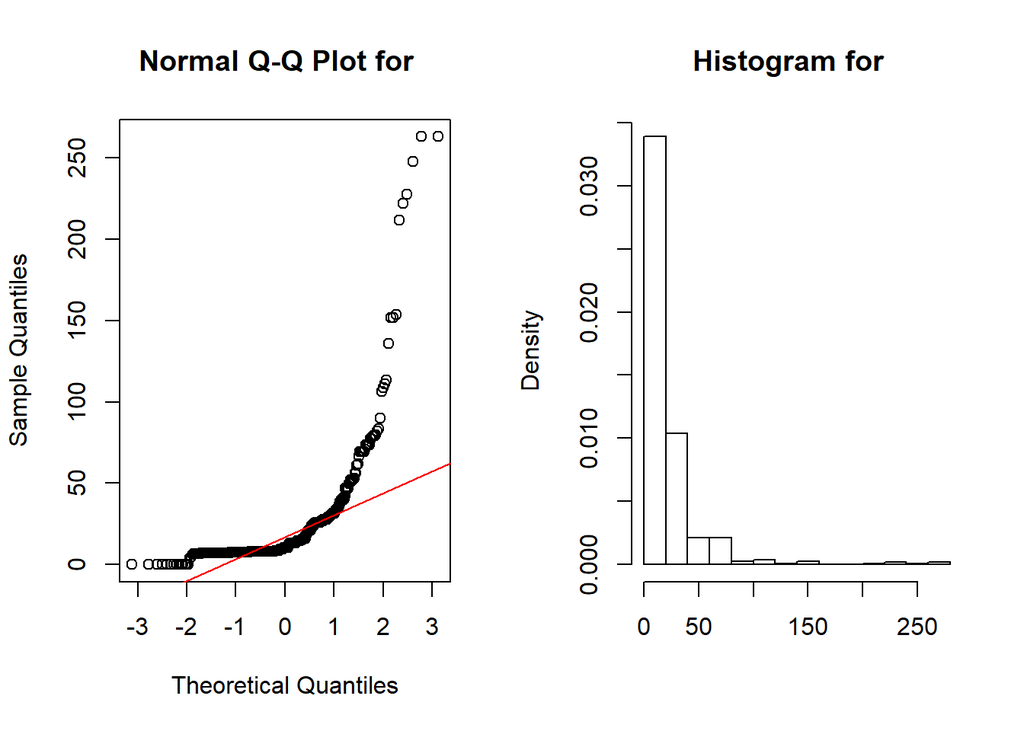

```r
par(mfrow=c(1,2))
qqnorm(Fare_sur_0, main = paste("Normal Q-Q Plot for ", colnames(Fare_sur_0)[1]))
qqline(Fare_sur_0, col="red")
hist(Fare_sur_0,
  main=paste("Histogram for ", colnames(Fare_sur_0)[1]),
xlab=colnames(Fare_sur_0)[1], freq = FALSE)
```

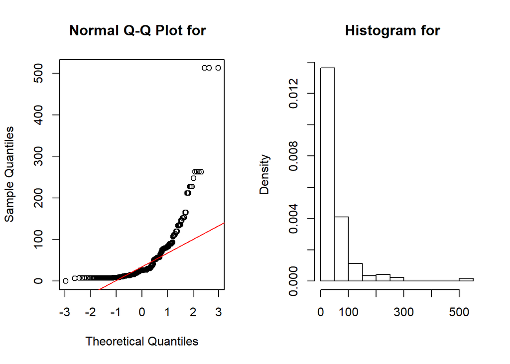

```r
par(mfrow=c(1,2))
qqnorm(Fare_sur_1, main = paste("Normal Q-Q Plot for ", colnames(Fare_sur_1)[1]))
qqline(Fare_sur_1, col="red")
hist(Fare_sur_1,
  main=paste("Histogram for ", colnames(Fare_sur_1)[1]),
xlab=colnames(Fare_sur_1)[1], freq = FALSE)
```

```r
# Test Shapirp para Fare
shapiro.test(Fare_sur_0)
```

```
##
##  Shapiro-Wilk normality test
##
## data:  Fare_sur_0
## W = 0.51304, p-value < 2.2e-16
```

```r
# Test Shapirp para Fare
shapiro.test(Fare_sur_1)
```

```
##
##  Shapiro-Wilk normality test
##
## data:  Fare_sur_1
## W = 0.59673, p-value < 2.2e-16
```

Dado los resultados anteriores, se observa que para las cuatro características consideradas sus correspondientes p-valores son inferiores al nivel de significación ($\alpha=$ 0.05). Por tanto, rechazamos la $H_0$ y concluimos con un 95% de confianza que los datos no se distribuyen normalmente.

### 4.2.2. Homogeneidad de la Varianza

Para estudiar la homogeneidad de varianzas se utiliza el test de Fligner-Killeen. Se trata de un test no paramétrico que compara las varianzas basándose en la mediana. Es una alternativa cuando no se cumple la condición de normalidad en las muestras. De tal forma que la hipótesis nula ($H_0$) y la alternativa ($H_1$) se pueden escribir de la siguiente forma:

**Hipótesis nula ($H_o$)**: Todas las varianzas de las poblaciones son iguales.

**Hipótesis alternativa ($H_1$)**: Al menos dos de ellos difieren.

**Zona de rechazo**. Para todo valor de probabilidad mayor que un nivel de significación $\alpha=$ 0.05, se acepta $H_o$ y se rechaza $H_1$.

Para realizar el test Fligner-Killeen se utiliza la función **`fligner.test()`**.

A continuación, se muestra la aplicación del test Fligner-Killeen para la característica cuantitativas Edad (Age) en función de la Supervivencia (Survived):

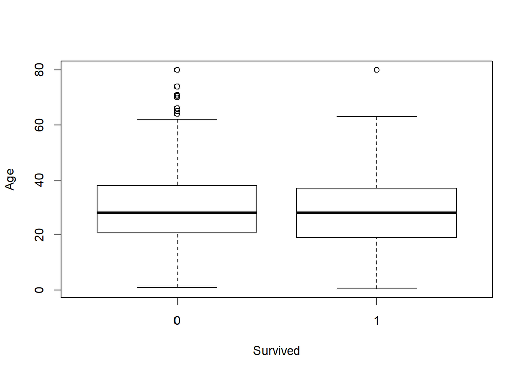

```r
# Test fligner para Age
boxplot(Age ~ Survived, data = clean_train)
```

```r
fligner.test(Age ~ Survived, data = clean_train)
```

```
##
##  Fligner-Killeen test of homogeneity of variances
##
## data:  Age by Survived
## Fligner-Killeen:med chi-squared = 2.2627, df = 1, p-value = 0.1325
```

Puesto que obtenemos un p-valor superior al nivel de significación ($\alpha=$ 0.05), aceptamos la hipótesis nula ($H_0$), es decir, de que las varianzas de ambas muestras son homogéneas.

A continuación, se muestra la aplicación del test Fligner-Killeen para característica Número de hermanos/cónyuges a bordo (SibSp) en función de la Supervivencia (Survived):

```r
# Test fligner para SibSp
fligner.test(SibSp ~ Survived, data = clean_train)
```

```
##
##  Fligner-Killeen test of homogeneity of variances
##
## data:  SibSp by Survived
## Fligner-Killeen:med chi-squared = 1.2514, df = 1, p-value = 0.2633
```

Puesto que obtenemos un p-valor superior al nivel de significación ($\alpha=$ 0.05), aceptamos la hipótesis nula ($H_0$), es decir, de que las varianzas de ambas muestras son homogéneas.

A continuación, se muestra la aplicación del test Fligner-Killeen para la característica Número de padres/hijos a bordo (Parch) en función de la Supervivencia (Survived):

```r
# Test fligner para Parch
fligner.test(Parch ~ Survived, data = clean_train)
```

```
##
##  Fligner-Killeen test of homogeneity of variances
##
## data:  Parch by Survived
## Fligner-Killeen:med chi-squared = 11.253, df = 1, p-value =
## 0.0007948
```

A continuación, se muestra la aplicación del test Fligner-Killeen para la característica Tarifa (Fare) en función de la Supervivencia (Survived):

```r
# Test fligner para Fare
fligner.test(Fare ~ Survived, data = clean_train)
```

```
##
##  Fligner-Killeen test of homogeneity of variances
##
## data:  Fare by Survived
## Fligner-Killeen:med chi-squared = 96.253, df = 1, p-value <
## 2.2e-16
```

Puesto que obtenemos un p-valor inferior al nivel de significación ($\alpha=$ 0.05), rechazamos la hipótesis nula ($H_0$), y podemos concluir que las varianzas son significativamente diferentes.

## 4.3. Aplicación de pruebas estadísticas para comparar los grupos de datos.

```r
# Nivel de significancia
sig_level = 0.05
```

En este apartado se aplicará un contraste de hipótesis sobre dos muestras para determinar si la supervivencia dependiendo de otra variable categórica. Para comparar la dependencia entre dos variables categóricas se utilizará la prueba de $\chi^{2}$ (chi-cuadrado).

El contraste de hipótesis a realizar se expresa así:

**Hipótesis nula ($H_o$)**. Los dos factores son independientes.

**Hipótesis alternativa ($H_1$)**: Los dos factores son dependentes.

**Zona de rechazo**. Para todo valor de probabilidad mayor que un nivel de significación $\alpha=$ 0.05, se acepta $H_o$ y se rechaza $H_1$.

Una vez establecido las hipótesis para cada conjunto de variables categóricas consideradas se construirá su correspondiente tabla de contingencia y se aplicará el test chi-cuadrado, para ello se empleará la función `chisq.test()`.

A continuación, se calculan la prueba $\chi^{2}$ para varios pares de variables categóricas.

#### Supervivencia vs Sexo (Sex)

```r
tbl = table(clean_train$Survived, clean_train$Sex)
tbl
```

```
##
##       F   M
##   0  81 468
##   1 233 109
```

Aplicamos la función chisq.test a la tabla de contingencia tbl

```r
## Test chi
chisq.test(tbl)
```

```
##
##  Pearson's Chi-squared test with Yates' continuity correction
##
## data:  tbl
## X-squared = 260.72, df = 1, p-value < 2.2e-16
```

Como el valor de p-valor es menor que el nivel de significancia de 0.05, por tanto rechazamos la hipótesis nula ($H_0$) y aceptamos la hipótesis alternativa. Por tanto, concluimos que la supervivenvia depende del sexo del pasajero (Sex)

#### Supervivencia vs Clase (Pclass)

```r
tbl = table(clean_train$Survived, clean_train$Pclass)
tbl
```

```
##
##       1   2   3
##   0  80  97 372
##   1 136  87 119
```

Aplicamos la función chisq.test a la tabla de contingencia tbl

```r
## Test chi
chisq.test(tbl)
```

```
##
##  Pearson's Chi-squared test
##
## data:  tbl
## X-squared = 102.89, df = 2, p-value < 2.2e-16
```

Como el valor de p-valor es menor que el nivel de significancia de 0.05, por tanto rechazamos la hipótesis nula ($H_0$) y aceptamos la hipótesis alternativa. Por tanto, concluimos que la supervivenvia depende la clase del pasajero (Pclass).

```r
tbl = table(clean_train$Survived, clean_train$FsizeD)
tbl
```

```
##
##     large singleton small
##   0    52       374   123
##   1    10       163   169
```

Aplicamos la función chisq.test a la tabla de contingencia tbl

```r
## Test chi
chisq.test(tbl)
```

```
##
##  Pearson's Chi-squared test
##
## data:  tbl
## X-squared = 74.537, df = 2, p-value < 2.2e-16
```

Como el valor de p-valor es menor que el nivel de significancia de 0.05, por tanto rechazamos la hipótesis nula ($H_0$) y aceptamos la hipótesis alternativa. Por tanto, concluimos que la supervivenvia depende del tamaño de la familia (FsizeD)

#### Supervivencia vs Titulo del Pasajero (Titulo)

```r
tbl = table(clean_train$Survived, clean_train$Title)
tbl
```

```
##
##     Master Miss  Mr Mrs Rare Title
##   0     17   55 436  26         15
##   1     23  130  81 100          8
```

Aplicamos la función chisq.test a la tabla de contingencia tbl

```r
## Test chi
chisq.test(tbl)
```

```
##
##  Pearson's Chi-squared test
##
## data:  tbl
## X-squared = 288.12, df = 4, p-value < 2.2e-16
```

Como el valor de p-valor es menor que el nivel de significancia de 0.05, por tanto rechazamos la hipótesis nula ($H_0$) y aceptamos la hipótesis alternativa. Por tanto, concluimos que la supervivenvia depende del titulo del pasajero (Title)

#### Supervivencia vs Cubierta del Camarote (Deck)

```r
tbl = table(clean_train$Survived, clean_train$Deck)
tbl
```

```
##
##       A   B   C   D   E   F   G   T  U1  U2  U3
##   0   8  12  24   8   8   5   2   1  21  94 366
##   1   7  35  35  25  24   8   2   0  19  74 113
```

Aplicamos la función chisq.test a la tabla de contingencia tbl

```r
## Test chi
chisq.test(tbl)
```

```
##
##  Pearson's Chi-squared test
##
## data:  tbl
## X-squared = 126.68, df = 10, p-value < 2.2e-16
```

Como el valor de p-valor es menor que el nivel de significancia de 0.05, por tanto rechazamos la hipótesis nula ($H_0$) y aceptamos la hipótesis alternativa. Por tanto, concluimos que la supervivenvia depende de la cubierta (Deck)

### 4.3.2. Correlaciones

En este apartado procedemos a realizar un análisis de correlación entre las distintas variables numéricas del conjunto de datos.

Cuando dos características o más tienen correlación, eso significa que se están explicando unas a otras al tiempo con lo que proporcionan solo poca o ninguna información nueva.

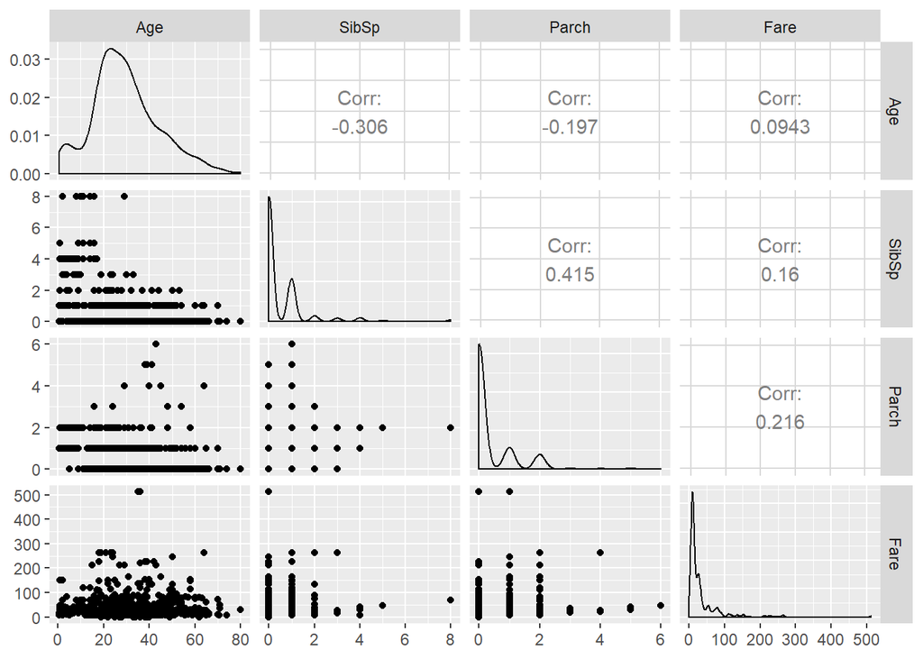

```r
# Calculamos las correlaciones.
corr_data <- select_if(clean_train, is.numeric)
corr_data <- select(corr_data, -PassengerId)

corr.res <- cor(corr_data)

# Mostramos las gráficas
ggpairs(corr_data)
```

La gráfica anterior muestra que existe una correlación positiva entre las variables **Parch** y **SibSp**. Esto tiene sentido debido a que ambas variables hacen referencia al tamaño de la familia que va a bordo.

### 4.3.2. Regresión Lineal logística.

Dado que la variable resultado (dependiente) solo pueda tomar dos valores (1=Vivo y 0=Muerto), la regresión logística será más adecuada que la regresión lineal.

La **regresión logística** es un tipo de análisis de regresión utilizado para predecir el resultado de una variable dicotómica dependiente, en función de una serie de variables independientes o predictoras. Dado que este modelo estima las probabilidades de ocurrencia, en lugar de utilizar un modelo aditivo que podría predecir valores fuera del rango [0,1], utiliza una escala transformada basada en una función logística

La estrategia por seguir será partir de un modelo donde la supervivencia dependa de la Edad (Age), la tarifa (Fare), el Número de hermanos/cónyuges a bordo (SibSp), el número de padres/hijos a bordo (Parch), la embarcación (Embarked), el sexo (Sex) y la clase (Pclass). Partiendo de esta modelo ser irá añadiendo y quitando variables con el propósito de mejorar el modelo.

En primer lugar, establecemos categorías de referencia para las variables cualitativas: “F” para la variable Sex, “S” para la variable Embarked, “1” para la variable Pclass, “small” para la variable Fsize, “Miss” para la variable Title, y “A” para la variable Title; para ello utilizamos la función `relevel()`.

```r
# Nivel de significancia
sig_level = 0.05

# Establecemos categoria de referencia conjunto de datos.
clean_train$SexR <- relevel(clean_train$Sex, ref="F")
clean_train$EmbarkedR <- relevel(clean_train$Embarked, ref="S")
clean_train$PclassR <- relevel(clean_train$Pclass, ref="1")
clean_train$FsizeD <- relevel(clean_train$Fsize, ref="small")
clean_train$TitleR <- relevel(clean_train$Title, ref="Miss")
clean_train$DeckR <- relevel(clean_train$Deck, ref="A")

# Establecemos categoria de referencia conjunto de pruebas
clean_test$SexR <- relevel(clean_test$Sex, ref="F")
clean_test$EmbarkedR <- relevel(clean_test$Embarked, ref="S")
clean_test$PclassR <- relevel(clean_test$Pclass, ref="1")
clean_test$FsizeD <- relevel(clean_test$Fsize, ref="small")
clean_test$TitleR <- relevel(clean_test$Title, ref="Miss")
clean_test$DeckR <- relevel(clean_test$Deck, ref="A")
```

Calculamos la supervivencia en función de las carácteristicas:

- Modelo 1. Survived = Age + SibSp + Parch + Fare + EmbarkedR + SexR + PclassR.
- Modelo 2. Survived = Age + SibSp + Parch + Fare + EmbarkedR + SexR + PclassR + FsizeD.
- Modelo 3. Survived = Age + SibSp + Parch + Fare + EmbarkedR + SexR + PclassR + TitleR
- Modelo 4. Survived = Age + SibSp + Parch + Fare + EmbarkedR + SexR + PclassR + DeckR
- Modelo 5. Survived = Age + SibSp + Parch + Fare + EmbarkedR + SexR + PclassR + FsizeD + TitleR + DeckR
- Modelo 6. Survived = Age + Fare + SexR + PclassR + FsizeD + TitleR
- Modelo 7. Survived = Age + Fare + SexR + PclassR + FsizeD + DeckR
- Modelo 8. Survived = Age + SexR + PclassR + FsizeD

```r
# Calculamos modelo
glm1.fit <- glm(factor(Survived) ~ Age + SibSp + Parch + Fare +
                                   EmbarkedR + SexR + PclassR,
                data = clean_train,
                family = "binomial")
# Obtenemos resumen
glm1.summary <- summary(glm1.fit)
#glm1.summary
```

```r
# Calculamos modelo
glm2.fit <- glm(factor(Survived) ~ Age + SibSp + Parch + Fare +
                                   EmbarkedR + SexR + PclassR +
                                   FsizeD,
                data = clean_train,
                family = "binomial")
# Obtenemos resumen
glm2.summary <- summary(glm2.fit)
#glm2.summary
```

```r
# Calculamos modelo
glm3.fit <- glm(factor(Survived) ~ Age + SibSp + Parch + Fare +
                                   EmbarkedR + SexR + PclassR +
                                   TitleR,
                data = clean_train,
                family = "binomial")
# Obtenemos resumen
glm3.summary <- summary(glm3.fit)
#glm3.summary
```

```r
# Calculamos modelo
glm4.fit <- glm(factor(Survived) ~ Age + SibSp + Parch + Fare +
                                   EmbarkedR + SexR + PclassR +
                                   DeckR,
                data = clean_train,
                family = "binomial")
# Obtenemos resumen
glm4.summary <- summary(glm4.fit)
#glm4.summary
```

```r
# Calculamos modelo
glm5.fit <- glm(factor(Survived) ~ Age + SibSp + Parch + Fare +
                                   EmbarkedR + SexR + PclassR +
                                   FsizeD + TitleR + DeckR,
                data = clean_train,
                family = "binomial")

# Obtenemos resumen
glm5.summary <- summary(glm5.fit)
#glm5.summary
```

```r
# Calculamos modelo
glm6.fit <- glm(factor(Survived) ~ Age + Fare +
                                   SexR + PclassR +
                                   FsizeD + TitleR,
                data = clean_train,
                family = "binomial")

# Obtenemos resumen
glm6.summary <- summary(glm6.fit)
#glm6.summary
```

```r
# Calculamos modelo
glm7.fit <- glm(factor(Survived) ~ Age + Fare +
                                   SexR + PclassR +
                                   FsizeD + DeckR,
                data = clean_train,
                family = "binomial")

# Obtenemos resumen
glm7.summary <- summary(glm7.fit)
#glm7.summary
```

```r
# Calculamos modelo
glm8.fit <- glm(factor(Survived) ~ Age +
                                   SexR + PclassR +
                                   FsizeD,
                data = clean_train,
                family = "binomial")

# Obtenemos resumen
glm8.summary <- summary(glm8.fit)
#glm8.summary
```

```r
aui_data <- AIC(glm1.fit, glm2.fit, glm3.fit, glm4.fit, glm5.fit, glm6.fit, glm7.fit, glm8.fit)
kable(aui_data) %>%
  kable_styling(bootstrap_options = "striped", full_width = F)
```

|  | df | AIC |
| --- | --- | --- |
| glm1.fit | 10 | 809.0809 |
| glm2.fit | 12 | 792.8541 |
| glm3.fit | 14 | 755.6265 |
| glm4.fit | 20 | 811.7659 |
| glm5.fit | 26 | 753.9042 |
| glm6.fit | 12 | 741.5767 |
| glm7.fit | 18 | 794.0856 |
| glm8.fit | 7 | 789.7273 |

```r
glm4.summary
```

```
##
## Call:
## glm(formula = factor(Survived) ~ Age + SibSp + Parch + Fare +
##     EmbarkedR + SexR + PclassR + DeckR, family = "binomial",
##     data = clean_train)
##
## Deviance Residuals:
##     Min       1Q   Median       3Q      Max
## -2.4558  -0.6022  -0.3983   0.6117   2.4677
##
## Coefficients:
##               Estimate Std. Error z value Pr(>|z|)
## (Intercept)   3.502094   0.685921   5.106 3.30e-07 ***
## Age          -0.033025   0.007567  -4.364 1.28e-05 ***
## SibSp        -0.340306   0.109512  -3.107  0.00189 **
## Parch        -0.097982   0.119297  -0.821  0.41146
## Fare          0.002707   0.002681   1.010  0.31252
## EmbarkedRC    0.516209   0.244584   2.111  0.03481 *
## EmbarkedRQ    0.316817   0.340829   0.930  0.35261
## SexRM        -2.699291   0.205361 -13.144  < 2e-16 ***
## PclassR2      0.143647   1.109066   0.130  0.89695
## PclassR3     -1.023828   1.174689  -0.872  0.38344
## DeckRB        0.029073   0.704977   0.041  0.96711
## DeckRC       -0.344894   0.657580  -0.524  0.59994
## DeckRD        0.489003   0.738516   0.662  0.50788
## DeckRE        0.919261   0.745893   1.232  0.21779
## DeckRF       -0.018349   1.327755  -0.014  0.98897
## DeckRG       -1.735648   1.661714  -1.044  0.29626
## DeckRT      -12.978863 535.411462  -0.024  0.98066
## DeckRU1      -0.686211   0.680247  -1.009  0.31309
## DeckRU2      -1.209092   1.248041  -0.969  0.33265
## DeckRU3      -1.203756   1.298147  -0.927  0.35378
## ---
## Signif. codes:  0 '***' 0.001 '**' 0.01 '*' 0.05 '.' 0.1 ' ' 1
##
## (Dispersion parameter for binomial family taken to be 1)
##
##     Null deviance: 1186.66  on 890  degrees of freedom
## Residual deviance:  771.77  on 871  degrees of freedom
## AIC: 811.77
##
## Number of Fisher Scoring iterations: 12
```

```r
glm4.coef <- coef(glm4.fit)
glm4.coef_exp <- exp(coef(glm1.fit))
data <- data.frame(Coeficiente = glm4.coef, Exp = glm4.coef_exp)
kable(data) %>%
  kable_styling(bootstrap_options = "striped", full_width = F)
```

[output not shown]

Del modelo anterior podemos concluir que:

- Para las variables Age, SibSp, EmbarkedRC, y SexRM, sus correspondientes p-valores son menores que 0.05, es decir, son significativas para el modelo.
- Para las variables Parch, Fare, EmbarkedRQ, PclassR2, PclassR3, DeckRB, DeckRC, DeckRD, DeckRE, DeckRF, DeckRG, DeckRT, DeckRU1, DeckRU2 y DeckRU3 su correspondientes p-valores son mayores que 0.05. Por tanto, no son estadísticamente significativas para el resultado y se pueden eliminar del modelo.

#### Predicción.

Ahora, empleando este modelo podemos proceder a realizar predicciones de la supervivencia con el conjunto de prueba.

```r
# Calculamos la probabilidad del conjunto de test
glm4.test_prob <- predict(glm4.fit, newdata = clean_test, type = "response")

# Calculamos un prediccion
test_threshold <- 0.75
glm4.test_pred <- ifelse(glm4.test_prob > test_threshold, 1, 0)

# Generamos la matriz de confusion
glm4.confusionMatrix <- confusionMatrix(data=factor(glm4.test_pred),
                                        reference=factor(clean_test$Survived))
glm4.confusionMatrix
```

```
## Confusion Matrix and Statistics
##
##           Reference
## Prediction   0   1
##          0 264  79
##          1   2  73
##
##                Accuracy : 0.8062
##                  95% CI : (0.765, 0.843)
##     No Information Rate : 0.6364
##     P-Value [Acc > NIR] : 2.765e-14
##
##                   Kappa : 0.5303
##
##  Mcnemar's Test P-Value : < 2.2e-16
##
##             Sensitivity : 0.9925
##             Specificity : 0.4803
##          Pos Pred Value : 0.7697
##          Neg Pred Value : 0.9733
##              Prevalence : 0.6364
##          Detection Rate : 0.6316
##    Detection Prevalence : 0.8206
##       Balanced Accuracy : 0.7364
##
##        'Positive' Class : 0
##
```

### 4.3.1. Random Forests

¿Qué variables son las más importantes para nuestro modelo de clasificación?

Un método habitual utilizado para responder esta pregunta es **Random Forest** (RF). El **RF** es un método de clasificación basado en la realización de múltiples árboles de decisión sobre muestras de un conjunto de datos Además, Random Forest permite obtener medidas acerca de la importancia que los diferentes predictores han tenido en el modelo, lo que permite en parte interpretar este. La importancia de los predictores se evalúa como el número de veces que han sido utilizados por los diversos árboles y su capacidad para reducir el índice de Gini en ellos

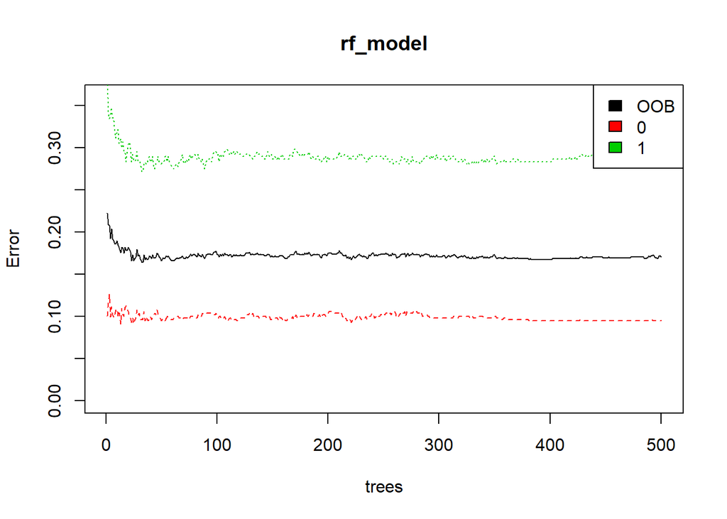

```r
# Set a random seed
set.seed(754)

# Build the model (note: not all possible variables are used)
rf_model <- randomForest(factor(Survived) ~ Pclass + Sex + Age + SibSp + Parch +
                                            Fare + Embarked + Title +
                                            FsizeD,
                                            data = clean_train)

# Show model error
plot(rf_model, ylim=c(0,0.36))
legend('topright', colnames(rf_model$err.rate), col=1:3, fill=1:3)
```

La línea negra muestra la tasa de error general que cae por debajo del 20%. Las líneas rojas y verdes muestran la tasa de error de “muerto” y “sobrevivió” respectivamente. Con alrededor del 10%, nuestro modelo parece ser bueno para predecir mejor la muerte que la supervivencia.

#### Importancia de las variables.

Ahora, veamos la importancia de la variable relativa al explorar la disminución media en Gini calculada en todos los árboles.

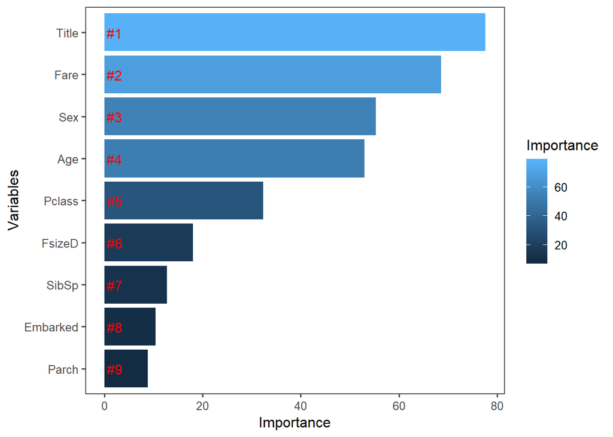

```r
# Get importance
importance    <- importance(rf_model)
varImportance <- data.frame(Variables = row.names(importance),
                            Importance = round(importance[ ,'MeanDecreaseGini'],2))

# Create a rank variable based on importance
rankImportance <- varImportance %>%
  mutate(Rank = paste0('#',dense_rank(desc(Importance))))

# Use ggplot2 to visualize the relative importance of variables
ggplot(rankImportance, aes(x = reorder(Variables, Importance),
    y = Importance, fill = Importance)) +
  geom_bar(stat='identity') +
  geom_text(aes(x = Variables, y = 0.5, label = Rank),
    hjust=0, vjust=0.55, size = 4, colour = 'red') +
  labs(x = 'Variables') +
  coord_flip() +
  theme_few()
```

#### Predicción.

```r
# Predict using the test set
forest.test_pred <- predict(rf_model, clean_test)

# Generamos la matriz de confusion
forest.confusionMatrix <- confusionMatrix(data=factor(forest.test_pred),
                                          reference=factor(clean_test$Survived))
forest.confusionMatrix
```

```
## Confusion Matrix and Statistics
##
##           Reference
## Prediction   0   1
##          0 242  25
##          1  24 127
##
##                Accuracy : 0.8828
##                  95% CI : (0.848, 0.912)
##     No Information Rate : 0.6364
##     P-Value [Acc > NIR] : <2e-16
##
##                   Kappa : 0.7464
##
##  Mcnemar's Test P-Value : 1
##
##             Sensitivity : 0.9098
##             Specificity : 0.8355
##          Pos Pred Value : 0.9064
##          Neg Pred Value : 0.8411
##              Prevalence : 0.6364
##          Detection Rate : 0.5789
##    Detection Prevalence : 0.6388
##       Balanced Accuracy : 0.8727
##
##        'Positive' Class : 0
##
```

#### Interpretación.

# 5. Representación de los resultados a partir de tablas y gráficas.

Durante el desarrollo de este trabajo en los apartados anteriores de mostraron los resultados obtenidos mediante diagramas de barras, boxplot y tablas.

# 6. Resolución del problema.

En este trabajo se trató de la problemática de determinar qué variables influyeron más sobre la supervivencia de los pasajeros a bordo del Titanic. Para llevar a cabo esta tarea se realizó se utilizó el *conjunto de datos de entrenamiento* y *conjunto de datos de prueba*.

Sobre este conjunto de datos se realizó una fase de preprocesamiento que incluye varias tareas de limpieza de datos, (tales como, conversiones, eliminación los valores perdidos o nulos), discretización de valores numéricos, etc. En la imputación de valores perdidos se pueden destacar el trabajo realizado en las variables Edad (Age) y Cubierta (Deck).

Para la imputación de los valores perdidos de la característica edad (Age) se empleó el algoritmo **MICE** (Multivariate Imputation by Chained Equations) de R. MICE se ha convertido en un método de referencia para tratar los datos perdidos.

La característica Deck se creó a partir del primer carácter de la variable Cabina (Cabin). Este carácter hace referencia al nivel de cubierta en el que estaba ubicada cabina. Las cabinas de una clase más alta estaban más cerca de la cubierta principal y de los botes salvavidas. Sin embargo, la característica Deck es la que más valores desconocidos presenta en el conjunto de datos. Debido a su gran número no se pueden eliminar las filas que tengan valores perdidos para este campo. Para imputar sus valores se utilizó los valores $U1$, $U2$ y $U3$, estos valores se asignan en función de la clase del pasajero.

Se realizaron pruebas estadísticas para comprobar las dependencias entre Supervivencia y otras variables categóricas del conjunto de datos. Se identifico que existen evidencias estadísticas de dependencias entre la Supervivencia y las variables categóricas: Sexo (Sex), Clase (Pclass), Tamaño de la familia (FsizeD), Titulo (Title) y Cubierta (Deck).

En este trabajo se utilizaron los clasificadores **Random Forest** (RF) y **Regresión Logística** (LR) con el propósito de construir un modelo que permita predecir la supervivencia a partir de un conjunto de pruebas.

El clasificador **Random Forest** también nos permite medir la importancia de las variables predictoras en el modelo de clasificación. El clasificador **RF** encontró que las variables *SibSp*, *Embarked* y *Parch* no parecen jugar un rol significante en la determinación de la supervivencia. Se podrían eliminar estas características para observar si existe una mejora en el modelo.

En ambos modelos **RF** y **LR** no indican que las variables Age y Sex influyen en la supervivencia. Sin embargo, el modelo **RF** también considera importantes las variables Fare, Title y Pclass. Mientras que el modelo **LR** considera que las variables SibSp y EmbarkedRC son significativas. Al analizar estas discrepancias podríamos posicionarnos en el lado del modelo **RF** debido a que da mayor importancia a variables Fare y Pclass que son socioeconómicas y estas si pueden influir en la supervivencia.

Por otra parte, si comparamos los resultados obtenidos de la predicción entre el *LR* y el *RF* se observa que tienen una **exactitud** del 80.6220096 % y 88.277512 % respectivamente. Por tanto, el clasificador *RF* es superior al clasificador de *RL*.

Como tarea adicional se puede plantear discretizar la variable Edad (Age). Si tenemos en consideración que las mujeres y niños tienen prioridad en el momento de abordar los botes salvavidas. El discretizar esta variable (por ejemplo: niño, joven, adulto, y anciano) puede convertir esta nueva una variable que puede influir en la supervivencia.

Otro cambio podría incluir mejorar la creación de la variable Título. Por ejemplo, los valores ‘Lady’, ‘Sir’, y ‘Jonkheer’ se pueden mapear a un valor de ‘Royalty’ en lugar de ‘Rare Title’. Este cambio resalta la condición socioeconómica del pasajero. Este factor puede influir en la supervivencia.

# Contribuyentes

| Contribuciones | Firma |
| --- | --- |
| Investigaciones previas | Edison Muzo |
| Redacción de las respuestas | Edison Muzo |
| Desarrollo código | Edison Muzo |

# References

Baayen, R Harald. 2008. *Analyzing Linguistic Data: A Practical Introduction to Statistics Using R*. Cambridge University Press.

Buuren, S van, and Karin Groothuis-Oudshoorn. 2010. “Mice: Multivariate Imputation by Chained Equations in R.” *Journal of Statistical Software*, 1–68.

Calvo, Mireia, Laia Subirats, and Diego Pérez. n.d. “Introducción a La Limpieza Y análisis de Los Datos.” *UOC*, 33.

datascienceplus. 2019. “Imputing Missing Data with R; Mice Package.” https://datascienceplus.com/imputing-missing-data-with-r-mice-package/. \url{https://datascienceplus.com/imputing-missing-data-with-r-mice-package/}.

Han, Jiawei, Micheline Kamber, and Data Mining. 2001. “Concepts and Techniques.” *Morgan Kaufmann* 340: 94104–93205.

Hothorn, Torsten, and Brian S Everitt. 2014. *A Handbook of Statistical Analyses Using R*. CRC press.

kaggle. 2019a. “Titanic: Machine Learning from Disaster: Overview.” https://www.kaggle.com/c/titanic/overview/tutorials. \url{https://www.kaggle.com/c/titanic/overview/tutorials}.

———. 2019b. “Titanic: Machine Learning from Disaster: Tutorial.” https://www.kaggle.com/c/titanic/overview. \url{https://www.kaggle.com/c/titanic/overview/tutorials}.

Osborne, Jason W. 2010. “Data Cleaning Basics: Best Practices in Dealing with Extreme Scores.” *Newborn and Infant Nursing Reviews* 10 (1): 37–43.

Risdal, Megan. 2019. “Exploring Survival on the Titanic.” https://www.kaggle.com/mrisdal/exploring-survival-on-the-titanic. \url{https://www.kaggle.com/mrisdal/exploring-survival-on-the-titanic}.

Squire, Megan. 2015. *Clean Data*. Packt Publishing Ltd.

Teetor, Paul. 2011. *R Cookbook: Proven Recipes for Data Analysis, Statistics, and Graphics*. " O’Reilly Media, Inc.".

Williams, Steven. 2019. “Titanic Survival (Logistic Regression).” https://www.kaggle.com/drwilliamssteven/titanic-survival-logistic-regression. \url{https://www.kaggle.com/drwilliamssteven/titanic-survival-logistic-regression}.